# Repair Cafés pelo mundo: o que dá para consertar?

Análise estatística dos fatores associados ao sucesso de reparos colaborativos (2015–2026)

Autores

Igor Marcon

Kevin Schelesting

Gabriele Henrique Pedro Sardá

Gabriel

Vinícius Eduardo Batista

Data de Publicação

27/11/2026

# 1 Introdução

Muitos objetos são descartados quando quebram, mesmo quando ainda poderiam ser consertados. Em parte isso acontece porque consertar pode sair caro, e alguns produtos são difíceis de abrir ou não têm peças de reposição. Os *Repair Cafés* surgiram nesse contexto: são encontros gratuitos, que começaram nos Países Baixos em 2009, em que as pessoas levam objetos quebrados e tentam consertá-los com a ajuda de voluntários (Charter & Keiller, 2014).

Parte desses cafés registra seus atendimentos na plataforma *Repair Monitor*, com informações sobre o produto, o defeito, uma nota de reparabilidade dada pelo voluntário e o resultado do conserto. Com esses registros é possível ver quais consertos costumam dar certo e o que aparece com mais frequência quando eles falham.

Neste trabalho analisamos os atendimentos registrados entre 2015 e 2026. Nossos objetivos foram:

1. Descrever os atendimentos e ver como a taxa de sucesso mudou ao longo dos anos;
2. Comparar a taxa de conserto entre categorias de produto e entre os países com mais registros;
3. Verificar se a nota de reparabilidade e a idade do produto estão associadas ao conserto completo;
4. Levantar os motivos de falha mais comuns e ver se consultar fontes de informação (manuais, vídeos, iFixit, IA generativa) está associado ao resultado.

# 2 Materiais e Métodos

## 2.1 Fonte dos dados e limpeza

Os dados vêm do *TidyTuesday* de 07/04/2026, que disponibilizou uma extração do *Repair Monitor*, plataforma da Repair Café International onde os cafés registram seus atendimentos. São duas tabelas: `repairs.csv`, com os dados de cada atendimento, e `repairs_text.csv`, com os campos de texto, como o motivo da falha e a fonte de informação consultada. A tabela principal tinha 178.749 registros.

A limpeza foi feita no R (versão 4.6.1) com os pacotes do `tidyverse` (Wickham et al., 2019), no script `R/01_importacao_limpeza.R`. Os passos foram:

- tiramos 66 linhas cujo `repair_id` aparecia duas vezes com produto e data diferentes. Como as duas tabelas são ligadas por esse código, não dava para saber qual texto era de qual conserto;
- deixamos o resultado em três níveis (*Não consertado*, *Parcial* e *Consertado*). Alguns registros vinham com “ja” (sim, em holandês) e foram tratados como consertados. Descartamos registros sem resultado e com data depois de 07/04/2026, dia da publicação do banco;
- consideramos válido só o ano de fabricação entre 1900 e o ano do atendimento, e com ele calculamos a idade do produto. Notas de reparabilidade fora da escala de 1 a 10 (na prática, notas 0) viraram `NA`;
- traduzimos para o português os nomes dos 25 países, das 14 categorias de produto e dos motivos de falha;
- a fonte de informação consultada era texto livre, em várias línguas. Agrupamos por palavras-chave em seis tipos: *IA generativa*, *YouTube*, *iFixit*, *Manual ou fabricante*, *Internet (sites e buscas)* e *Outra*.

Depois disso juntamos as duas tabelas pelo `repair_id`. A base final ficou com 178.676 atendimentos, de 448 *Repair Cafés*, envolvendo 1.952 tipos de produto.

## 2.2 Métodos Estatísticos

Para a análise descritiva, calcularam-se frequências absolutas, relativas e estimativas pontuais da taxa de sucesso completo (`resultado == "Consertado"`), acompanhadas de intervalos de confiança de 95% obtidos pelo método de Wilson com correção de continuidade (`prop.test`). Nas análises longitudinais, restringiu-se o recorte aos anos completos com volume consolidado (2017 a 2025), avaliando-se a tendência linear nas proporções anuais de sucesso por meio do teste de tendência de Cochran-Armitage (`prop.trend.test`).

Para investigar associações entre variáveis categóricas (categoria do produto, país e consulta prévia a informações técnicas) e o desfecho do reparo, aplicou-se o teste qui-quadrado de Pearson ($\chi^2$), complementado pelo coeficiente $V$ de Cramér como medida de tamanho de efeito, definido por:

$$V = \sqrt{\frac{\chi^2}{N \cdot \min(r - 1,\, c - 1)}}$$

onde $N$ representa o tamanho amostral total e $r$ e $c$ correspondem, respectivamente, ao número de linhas e colunas da tabela de contingência. A comparação das distribuições do índice de reparabilidade entre os três níveis de desfecho foi conduzida pelo teste não paramétrico de Kruskal-Wallis, dada a natureza ordinal discreta e a assimetria da escala.

Por fim, ajustou-se um modelo de regressão logística binária (GLM com função de ligação *logit*) para estimar o efeito conjunto da categoria do produto e da faixa etária do item (*Até 5 anos*, *6 a 10 anos*, *11 a 20 anos* e *Mais de 20 anos*) sobre a probabilidade de conserto completo ($n = 63.968$ registros com idade válida). Os resultados são expressos em razões de chances (*Odds Ratios* — OR) com respectivos intervalos de confiança de 95% de Wald, adotando-se como referência a categoria de maior volume (*Eletrodomésticos elétricos*) e produtos mais recentes (*Até 5 anos*). Todas as análises adotaram nível de significância de $\alpha = 0{,}05$.

# 3 Resultados e Discussão

## 3.1 Panorama Geral e Evolução Temporal

Dos 178.676 atendimentos analisados, **63,1%** (IC 95%: 62,9% a 63,3%) resultaram em conserto completo, conforme detalhado na Tabela 1. Somando-se os reparos parciais, observa-se que a maioria expressiva dos objetos levados aos eventos recebe alguma recuperação funcional, evitando o descarte imediato.

Tabela 1: Distribuição geral dos desfechos dos atendimentos registrados nos Repair Cafés.

| Desfecho | Registros | Proporção |
| --- | --- | --- |
| Não consertado | 43.089 | 24,1% |
| Parcial | 22.852 | 12,8% |
| Consertado | 112.735 | 63,1% |

Ao avaliar o comportamento histórico entre 2017 e 2025 (Figura 1), verifica-se forte expansão no volume de registros após a retomada das atividades presenciais pós-pandemia, acompanhada de variação estatisticamente significativa na proporção de sucesso ao longo dos anos ($p = 0,005$, teste de tendência de Cochran-Armitage).

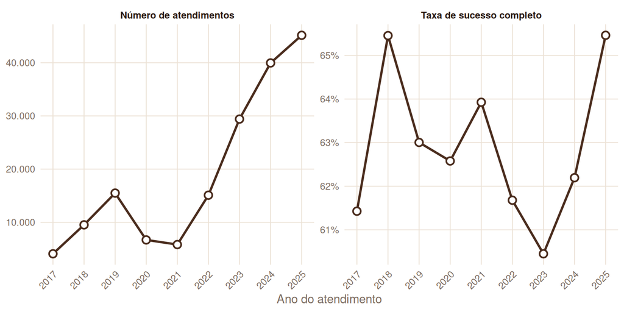

Figura 1: Volume anual de atendimentos (esquerda) e taxa de sucesso completo (direita) entre 2017 e 2025.

## 3.2 Desempenho por Categoria de Produto e País

A taxa de sucesso varia substancialmente conforme a natureza do objeto ($\chi^2 = 19.684,3$, $p < 0,001$, $V = 0,235$). Como ilustrado na Figura 2, categorias com mecânica mais acessível ou menor integração eletrônica — como **Têxteis** (92,3%) e **Ferramentas não elétricas** (90,0%) — apresentam índices de êxito superiores, enquanto itens miniaturizados ou altamente integrados, como **Imagem e som** (45,8%), exibem maior dificuldade técnica.

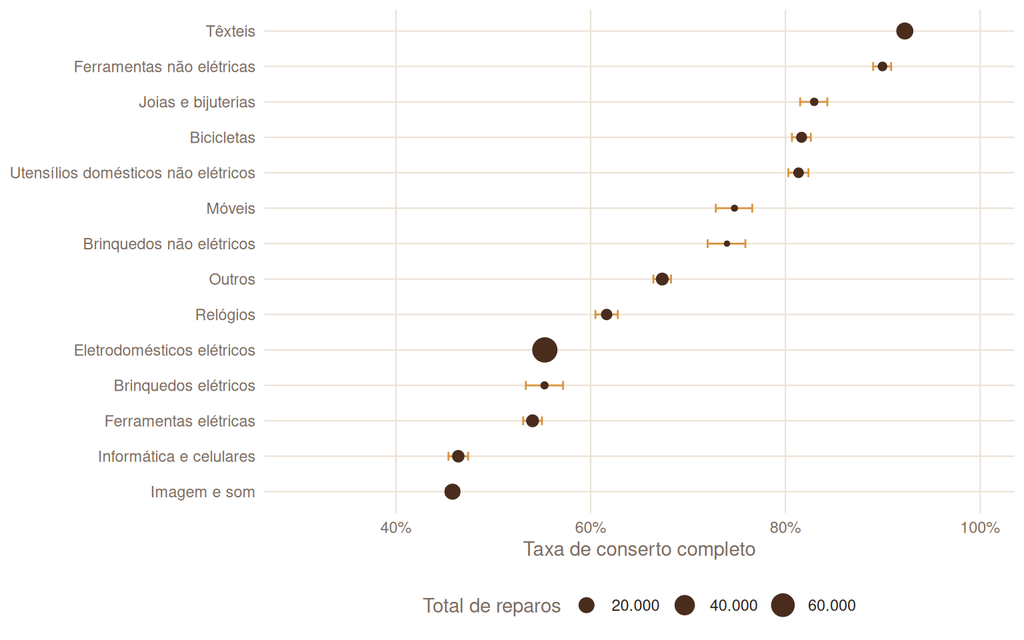

Figura 2: Taxa de conserto completo (com IC 95%) por categoria de produto.

Na comparação geográfica entre os 11 países com ao menos 1.000 registros (Tabela 2), observa-se associação significativa entre o país e o desfecho ($\chi^2 = 1.085,1$, $p < 0,001$), embora com tamanho de efeito modesto ($V = 0,078$), sugerindo consistência operacional da metodologia dos *Repair Cafés* em diferentes contextos nacionais.

Tabela 2: Taxa de sucesso completo nos países com 1.000 ou mais registros.

| País | Atendimentos | Consertados | Taxa de Sucesso | IC 95% |
| --- | --- | --- | --- | --- |
| Israel | 1.559 | 1.210 | 77,6% | [75,4% ; 79,6%] |
| Estados Unidos | 3.585 | 2.543 | 70,9% | [69,4% ; 72,4%] |
| Canadá | 7.626 | 5.252 | 68,9% | [67,8% ; 69,9%] |
| Austrália | 7.079 | 4.864 | 68,7% | [67,6% ; 69,8%] |
| Reino Unido | 37.684 | 24.668 | 65,5% | [65,0% ; 65,9%] |
| Alemanha | 4.509 | 2.923 | 64,8% | [63,4% ; 66,2%] |
| Países Baixos | 90.790 | 56.543 | 62,3% | [62,0% ; 62,6%] |
| Bélgica | 1.975 | 1.204 | 61,0% | [58,8% ; 63,1%] |
| Áustria | 1.248 | 748 | 59,9% | [57,2% ; 62,7%] |
| Espanha | 1.711 | 953 | 55,7% | [53,3% ; 58,1%] |
| França | 19.724 | 10.970 | 55,6% | [54,9% ; 56,3%] |

## 3.3 Índice de Reparabilidade, Idade do Produto e Modelo Logístico

A nota de reparabilidade atribuída pelos técnicos apresentou forte discriminação entre os desfechos ($H = 21.870,8$, $p < 0,001$, teste de Kruskal-Wallis). Enquanto itens totalmente consertados obtiveram mediana de **8,0** (média 7,5), os não consertados registraram mediana de apenas **4,0**.

No ajuste da regressão logística múltipla ($n = 63.968$, $\text{AIC} = 81.271,1$), controlado simultaneamente pela categoria do item e pela faixa etária (Figura 3), evidencia-se que a idade do produto exerce impacto significativo sobre a probabilidade de recuperação, refletindo mudanças históricas no design industrial, disponibilidade de peças e facilidade de abertura dos aparelhos.

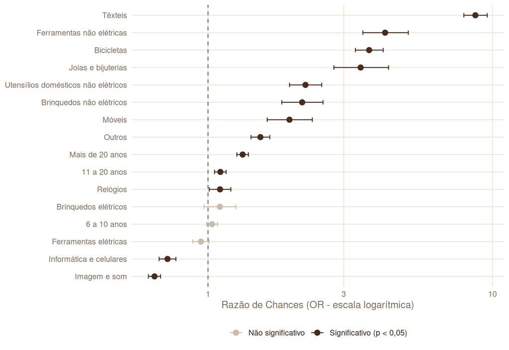

Figura 3: Razões de chances (Odds Ratios e IC 95%) para o sucesso do conserto segundo categoria e faixa etária.

## 3.4 Motivos de Falha e Fontes de Informação Técnica

Entre os registros em que o reparo não foi concluído com êxito e houve justificativa documentada (Tabela 3), destacam-se **Sem solução técnica** (20,8%) e **Peça indisponível no evento** (17,8%), evidenciando barreiras estruturais ligadas ao projeto fechado dos fabricantes e à cadeia de reposição de componentes.

Tabela 3: Principais motivos documentados para a falha no conserto.

| Motivo da Falha | Registros | Proporção |
| --- | --- | --- |
| Sem solução técnica | 5.553 | 20,8% |
| Peça indisponível no evento | 4.748 | 17,8% |
| Defeito não identificado | 3.674 | 13,8% |
| Desgaste excessivo | 3.352 | 12,6% |
| Produto não abre | 2.309 | 8,7% |
| Peça indisponível no mercado | 2.189 | 8,2% |
| Peça cara demais | 2.177 | 8,2% |
| Conserto demorado demais | 1.233 | 4,6% |

Por fim, a consulta a fontes de informação técnica durante o atendimento mostrou associação significativa com o desfecho ($\chi^2 = 55,4$, $p < 0,001$). Na evolução recente das fontes utilizadas pelos voluntários (Figura 4), observa-se a consolidação de plataformas colaborativas e, nos últimos anos, a emergência do uso de ferramentas de **IA generativa** no apoio ao diagnóstico de falhas.

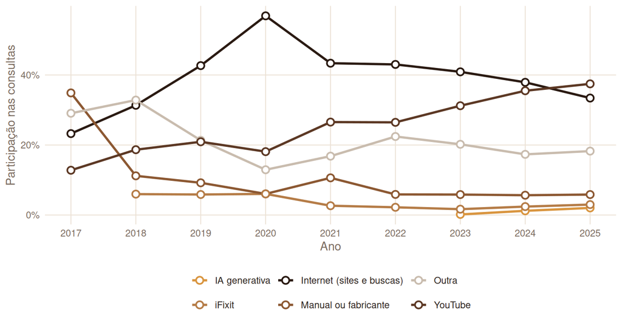

Figura 4: Participação de cada fonte de informação técnica nas consultas registradas, por ano (2017–2025).

# 4 Conclusão

A análise dos atendimentos registrados nos Repair Cafés mostrou que o resultado dos consertos varia de acordo com o tipo de produto e com suas características. A categoria do item apresentou diferenças nas taxas de sucesso, enquanto a nota de reparabilidade também se mostrou relacionada ao resultado final. Os produtos com avaliações mais altas de reparabilidade tiveram melhores resultados, o que faz sentido considerando que a facilidade de desmontagem e o acesso aos componentes podem interferir diretamente no trabalho dos voluntários.

A comparação entre os países também apontou diferenças, mas a associação encontrada foi pequena. Já a análise dos motivos de falha mostrou que nem todos os reparos deixam de ser concluídos pelas mesmas razões, o que evidencia a variedade de dificuldades enfrentadas durante os atendimentos. Em relação às fontes de informação, encontramos uma associação com o resultado dos consertos, mas não é possível concluir que consultar determinada fonte seja, por si só, responsável por aumentar as chances de sucesso.

É importante considerar que os dados utilizados representam apenas os atendimentos registrados na plataforma Repair Monitor. Portanto, os resultados não necessariamente representam todos os Repair Cafés existentes, principalmente aqueles que não registram suas atividades. Além disso, algumas informações dependem do preenchimento dos voluntários, o que pode gerar registros incompletos.

De modo geral, o estudo permitiu identificar quais características aparecem associadas aos melhores resultados nos atendimentos. Mais do que apontar uma única causa para o sucesso dos reparos, os dados mostram que o tipo de produto, sua condição de reparabilidade e as dificuldades encontradas durante o atendimento precisam ser considerados em conjunto para entender por que alguns consertos são concluídos e outros não.

# 5 Referências Bibliográficas

- CHARTER, M.; KEILLER, S. **Grassroots Innovation and the Circular Economy: A Global Survey of Repair Cafés and Hackerspaces**. Farnham: The Centre for Sustainable Design, University for the Creative Arts, 2014.
- OPEN REPAIR ALLIANCE. **Open Repair Data Standard & Repair Monitor Dataset**. 2026. Disponível em: https://openrepair.org. Acesso em: 24 nov. 2026.
- R CORE TEAM. **R: A Language and Environment for Statistical Computing**. Vienna: R Foundation for Statistical Computing, 2026. Disponível em: https://www.R-project.org/.
- WICKHAM, H. et al. Welcome to the tidyverse. **Journal of Open Source Software**, v. 4, n. 43, p. 1686, 2019. DOI: 10.21105/joss.01686.

# 6 Declaração de Uso de Inteligência Artificial

Em conformidade com as diretrizes da disciplina, declara-se que ferramentas de inteligência artificial generativa foram utilizadas como apoio na estruturação do documento em Quarto Markdown, revisão da redação acadêmica e depuração de código R para visualização de dados. Todas as análises estatísticas, interpretações e validações dos resultados foram conduzidas e verificadas pelos integrantes do grupo.